# Hypothesis Testing

## Inferential Analysis

Inferential statistics is the use of a sample to make reasonable guesses about the larger population.

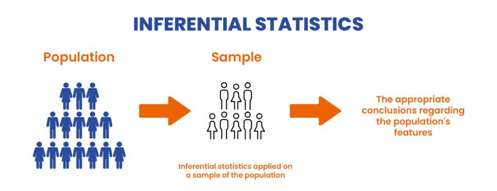

image: brainalyst

## Confidence Intervals

Let’s refresh our what we know about CIs.

Recall we have a 95% certainty that our population mean will fall between the two red lines.

And 5% of the time, our population mean could fall outside of that zone.

$$(-5,0)-\stackrel{\mu}{|}--\stackrel{\mu}{|}---(0,0)---\color{red}\vert-\stackrel{\mu}{|}-\stackrel{\mu}{|}-\stackrel{\mu}{|}-\stackrel{\mu}{|}-\stackrel{\mu}{|}-\stackrel{\mu}{|}-\color{red}\vert--\stackrel{\mu}{|}- (5,0)$$

Any values within the confidence intervals were reasonable estimates of the population parameter and any values outside of the confidence intervals were not reasonable estimates.

## Hypothesis Testing

We’ll spend some time on both of these concepts, as they can be difficult to understand.

Null Hypothesis there is no difference in the populations parameter you are testing within your sample.

Alternative Hypothesis there is a difference in the population parameter you are testing within your sample.

## Null Hypothesis $H_0$

If this is true, it suggests that any changes are because of random chance and not because of a relationship between variables.

If this is false, it suggests that we can reject the $H_0$ and accept our alternative hypothesis.

It’s important to understand, that we are only reject the $H_0$ , and not confirming anything, other than the relationship expressed in the null is not occurring within our sample.

## Alternative Hypothesis $H_A$

This is essentially what we are looking (the goal of the study) for within our sample.

We only adopt the this, if we have rejected the $H_0$ hypothesis.

## Steps in Hypothesis Testing

1.) Define or frame our null and alternative hypothesis

2.) Decide on our test statistic and significance level (We’ll get here over the upcoming weeks)

3.) Decide on our sampling distribution

4.) Do the math 🧮

5.) Then ask, do we reject or retain the null?

## Framing our Hypothesis Example 1

Let’s consider an example involving the mean weight loss of a new diet program that suggest a 5 pound weight loss within a three days.

$H_0$: The mean (our population parameter) weight loss for the individuals within our sample will have no change or they’ll add on weight.

$H_A$: The mean weight loss for the individuals within our sample will be 5 pounds or greater.

## Framing our Hypothesis Example 2

Let’s consider a new medication that is alleging to reduce blood pressure in men a week after taking it.

$H_0$: The mean reduction in blood pressure for patients taking the new medication is equal to 0 mmHg (no change) or worsen blood pressure.

$H_A$: The mean reduction in blood pressure for patients taking the new medication is greater than 0 mmHg.

## Type 1 & Type 2 Error

Type I = False Positive

#### Rejecting a true null hypothesis

Type II = False Negative

#### Retaining a false null hypothesis

[figure not shown]

## Type 1 & Type 2 Error

[figure not shown]

image: Reddit

## Type 1 & Type 2 Error

[figure not shown]

image: twitter